# Network Analytics (2623) — Group Assignment 3

# INSTRUCTIONS

- This is a group assignment.
- Submit your answer digitally as two files through Moodle:
  - An R markdown file (extension **Rmd**). Use the template provided to you and provide your answers (both code and text) below each question.
  - An **HTML** file “knitted” by RStudio including all the results and plots.
- Follow the Style Guide (available on Moodle). You can be penalized on up to 20% in each question for which you do not follow the Style Guide.
- Questions regarding the assignment should be posted exclusively on the respective discussion forum on Moodle.
- **Deadline:** Wednesday, 20 May 2026, 23:59 (Lisbon time)

**Warning:** The detection of any form of plagiarism in your work means the assignment will be graded with ZERO points.

# The Global Airline Network

Airline route networks shape how people, goods, and — relevant to this assignment — diseases and information move around the world. Some airports serve as critical hubs connecting entire regions, while others operate at the periphery with only a handful of routes. Understanding diffusion on this network has direct implications for public health, marketing, and strategic airline planning.

In this assignment we will analyze diffusion processes, seeding strategies, and link prediction on the global airline route network using data from [OpenFlights.org](https://openflights.org/data).

## Data dictionaries

### `airports.dat`

| Column | Field | Type | Description |
| --- | --- | --- | --- |
| 1 | `airport_id` | integer | OpenFlights airport ID |
| 2 | `name` | string | Airport name |
| 3 | `city` | string | City |
| 4 | `country` | string | Country |
| 5 | `iata` | string | 3-letter IATA code (e.g. “LIS”) |
| 6 | `icao` | string | 4-letter ICAO code (e.g. “LPPT”) |
| 7 | `latitude` | numeric | Latitude in decimal degrees |
| 8 | `longitude` | numeric | Longitude in decimal degrees |
| 9 | `altitude` | integer | Altitude in meters |
| 10 | `utc_offset` | numeric | UTC offset in hours |
| 11 | `dst` | string | Daylight Saving Time type |
| 12 | `timezone` | string | Timezone (tz database format) |
| 13 | `type` | string | Type (airport, station, port, unknown) |
| 14 | `source` | string | Data source |

### `routes.dat`

| Column | Field | Type | Description |
| --- | --- | --- | --- |
| 1 | `airline` | string | Airline IATA/ICAO code |
| 2 | `airline_id` | integer | Airline OpenFlights identifier |
| 3 | `source_airport` | string | Source airport IATA/ICAO code |
| 4 | `source_airport_id` | integer | Source airport OpenFlights identifier |
| 5 | `dest_airport` | string | Destination airport IATA/ICAO code |
| 6 | `dest_airport_id` | integer | Destination airport OpenFlights ID |
| 7 | `codeshare` | string | “Y” if codeshare, empty otherwise |
| 8 | `stops` | integer | Number of stops (0 = direct) |
| 9 | `equipment` | string | Aircraft types |

**Note:** Some fields contain `\N` indicating missing values.

## Setup and data loading

Place `airports.dat` and `routes.dat` in the **same folder** as this `.Rmd` file. When knitting, R automatically looks in that folder — no `setwd()` needed.

```r
library(data.table)
library(ggplot2)
library(igraph)

# ---- airports ----------------------------------------------------------------
dt.airports <- fread("airports.dat", header = FALSE, na.strings = "\\N")
colnames(dt.airports) <- c("airport_id", "name", "city", "country", "iata", "icao",
                           "latitude", "longitude", "altitude", "utc_offset",
                           "dst", "timezone", "type", "source")
dt.airports <- dt.airports[type == "airport"]

# ---- routes ------------------------------------------------------------------
dt.routes <- fread("routes.dat", header = FALSE, na.strings = "\\N")
colnames(dt.routes) <- c("airline", "airline_id", "source_airport", "source_airport_id",
                         "dest_airport", "dest_airport_id", "codeshare", "stops", "equipment")
dt.routes[, source_airport_id := as.numeric(source_airport_id)]
dt.routes[, dest_airport_id   := as.numeric(dest_airport_id)]
dt.routes <- dt.routes[!is.na(source_airport_id) & !is.na(dest_airport_id)]
```

You will likely also need (install with `install.packages()` if missing):

```r
install.packages("visNetwork")
```

## Helper: SIR simulator with fixed seeds

`igraph::sir()` is convenient but chooses one random seed internally, so it cannot be used for question C.1, which requires comparing fixed seed sets. Use the helper below instead. It is a discrete-time SIR: each step, every infected node infects each susceptible neighbor independently with probability $\beta$, and recovers with probability $\gamma$. It returns the final epidemic size as a fraction of $N$.

```r
simulate_sir <- function(g, seeds, beta, gamma, max_steps = 500) {
  n     <- vcount(g)
  state <- rep("S", n)
  state[seeds] <- "I"
  adj   <- as_adj_list(g)
  for (t in seq_len(max_steps)) {
    inf <- which(state == "I")
    if (length(inf) == 0) break
    sus <- which(state == "S")
    n_inf_nb <- if (length(sus) > 0)
      vapply(adj[sus], function(nb) sum(state[nb] == "I"), integer(1))
    else integer(0)
    new_inf <- sus[runif(length(sus)) < (1 - (1 - beta)^n_inf_nb)]
    new_rec <- inf[runif(length(inf)) < gamma]
    state[new_inf] <- "I"
    state[new_rec] <- "R"
  }
  mean(state != "S")  # fraction of nodes that were ever infected
}
```

# Questions

## Part A: Network Setup `[2 points]`

1. *(Easy)* Build the undirected airline graph from the routes data. Some routes in `dt.routes` reference `airport_id`s that are not in `dt.airports` — drop those routes first. Extract the giant connected component. Attach `country`, `latitude`, and `longitude` attributes to each node from `dt.airports`. *Hint: `graph_from_data_frame()` accepts a `vertices=` argument that attaches per-node attributes during graph construction; use `simplify()` to remove self-loops and parallel edges, `components()` to find each node’s membership, and `induced_subgraph()` to extract the giant component.* `[1 point]`

```r
# Drop routes referencing airports not in the airports table
valid.ids <- dt.airports$airport_id
dt.routes.clean <- dt.routes[
  source_airport_id %in% valid.ids & dest_airport_id %in% valid.ids]

# Select only the columns needed as node attributes
dt.vertices <- dt.airports[, .(airport_id, name, country, latitude, longitude)]

# Build undirected graph with node attributes attached at construction time
g.raw <- graph_from_data_frame(
  d = dt.routes.clean[, .(source_airport_id, dest_airport_id)],
  directed = FALSE,
  vertices = dt.vertices)

# Remove self-loops (airport to itself) and duplicate edges
g.simple <- simplify(g.raw)

# Identify and extract the giant connected component
comp <- components(g.simple)
giant.id <- which.max(comp$csize)
g <- induced_subgraph(g.simple, which(comp$membership == giant.id))
```

2. *(Easy)* Report the number of nodes, the number of edges, the density, and the mean degree of the giant component. Two sentences are enough. *Hint: `vcount(g)`, `ecount(g)`, `edge_density(g)`, `mean(degree(g))`.* `[1 point]`

```r
# Report the four basic structural properties of the giant component
cat("Nodes      :", vcount(g), "\n")
```

```
## Nodes      : 3188
```

```r
cat("Edges      :", ecount(g), "\n")
```

```
## Edges      : 18833
```

```r
cat("Density    :", round(edge_density(g), 6), "\n")
```

```
## Density    : 0.003707
```

```r
cat("Mean degree:", round(mean(degree(g)), 4), "\n")
```

```
## Mean degree: 11.8149
```

The giant component contains 3,188 airports and 18,833 undirected routes, with a density of 0.003707 and a mean degree of 11.81, indicating a sparse network where a small number of major hubs account for most connections.

## Part B: Diffusion `[7 points]`

1. *(Easy)* **Bass Model.** A low-cost carrier opens a new long-haul route. Model passenger uptake over the first 100 weeks using the Bass diffusion model
   $$F(t) =
   F(t-1) + p \cdot (1 - F(t-1)) + q \cdot (1 - F(t-1)) \cdot
   F(t-1)$$
   where the innovation rate $p$ captures travelers who learn of the route through advertising, and the imitation rate $q$ captures word-of-mouth from people who have already flown it. Simulate for 100 time steps using $(p, q) \in \{(0.01, 0.10), (0.03, 0.30), (0.10, 0.10), (0.01, 0.40)\}$. Using `ggplot2`, plot the four cumulative adoption curves on the same figure (one line per parameter pair, with a legend). Describe in 2–3 sentences how the inflection point of the curve shifts as $p$ and $q$ change. Which parameter pair would best describe a route that the airline is reluctant to advertise but that gains traction through traveler reviews? *Hint: implement the Bass model as a `for` loop over 100 timesteps; to plot four curves on one figure, build a long-format data.frame with one row per (param_pair, t) and use `aes(color = pair)` in `ggplot()`.* `[2 points]`

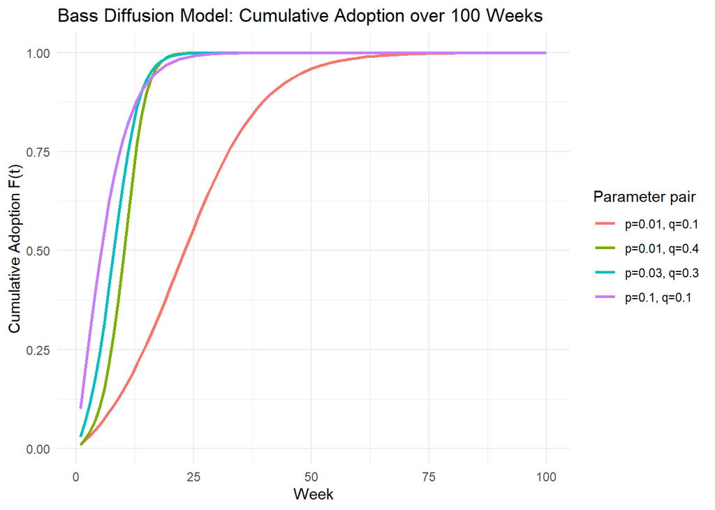

```r
# Define the four (p, q) parameter pairs to simulate
l.params <- list(
  c(p = 0.01, q = 0.10),
  c(p = 0.03, q = 0.30),
  c(p = 0.10, q = 0.10),
  c(p = 0.01, q = 0.40))

# Simulate Bass model for each pair and stack results into long format
# (tstep used instead of t to avoid shadowing R's t() transpose function)
dt.bass <- rbindlist(lapply(l.params, function(pq) {
  p <- pq["p"]
  q <- pq["q"]
  f <- numeric(100)
  f[1] <- p  # at t=1: no prior adopters, so imitation term is zero
  for (tstep in 2:100) {
    f[tstep] <- f[tstep - 1] +
      p * (1 - f[tstep - 1]) +        # innovation: advertising-driven adoption
      q * (1 - f[tstep - 1]) * f[tstep - 1]  # imitation: word-of-mouth adoption
  }
  data.table(
    t = 1:100,
    f = f,
    pair = paste0("p=", p, ", q=", q)
  )
}))

# Plot all four cumulative adoption curves on one figure
ggplot(dt.bass, aes(x = t, y = f, color = pair)) +
  geom_line(linewidth = 0.9) +
  labs(
    title = "Bass Diffusion Model: Cumulative Adoption over 100 Weeks",
    x = "Week",
    y = "Cumulative Adoption F(t)",
    color = "Parameter pair") +
  theme_minimal()
```

When p is low and q is high, the inflection point shifts earlier and the curve rises more steeply, driven by word-of-mouth rather than advertising. A higher p raises early adoption but flattens the eventual slope, while low values of both parameters delay take-off significantly. The pair (p=0.01, q=0.40) best describes a route the airline is reluctant to advertise but that gains traction through traveller reviews, as minimal advertising spend is offset by strong imitation effects that eventually drive rapid uptake.

2. *(Moderate)* **SIR on the airline network.** Run an SIR process on the giant component using `igraph::sir()` with `beta = 0.1, gamma = 0.01`. Run the simulation 50 times, each starting from a single uniformly random seed. Report (a) the mean and standard deviation of the final epidemic size (fraction of nodes ever infected), and (b) the mean time to peak infection. Note: preliminary runs in office hours suggested final epidemic sizes around 0.55–0.70 for these parameters; report your actual finding and comment if it differs. *Hint: `igraph::sir()` returns a list of 50 objects, each with fields `$times, $NS, $NI, $NR`. To collect the final epidemic size across all 50 runs into a vector, use:* `final_sizes <- sapply(sir_runs, function(s) tail(s$NR, 1) / vcount(g))`. *Then `mean(final_sizes)` and `sd(final_sizes)` give what you need. Adapt the same `sapply()` pattern for time-to-peak using `s$times[which.max(s$NI)]`.* `[2 points]`

```r
# Set seed and parameters
# (beta.rate / gamma.rate avoid shadowing R's built-in beta() and gamma()
# functions; these constants are re-used in C.1 and C.2)
set.seed(42)
beta.rate <- 0.1
gamma.rate <- 0.01

# Run 50 SIR simulations on graph g
sir.runs <- sir(g, beta = beta.rate, gamma = gamma.rate, no.sim = 50)

# Get final epidemic size and peak infection time per run
final.sizes <- sapply(sir.runs, function(s) tail(s$NR, 1) / vcount(g))
peak.times <- sapply(sir.runs, function(s) s$times[which.max(s$NI)])

# Print mean, standard deviation, and mean time to peak
cat("(a) Mean               :", mean(final.sizes), "\n")
```

```
## (a) Mean               : 0.9305583
```

```r
cat("(a) Standard Deviation :", sd(final.sizes), "\n")
```

```
## (a) Standard Deviation : 0.1919464
```

```r
cat("(b) Mean time to peak  :", mean(peak.times), "\n")
```

```
## (b) Mean time to peak  : 22.45025
```

```r
# Save the mean for Part C.2 reference
mean.b2 <- mean(final.sizes)
```

Across 50 simulations, the mean final size was 0.93 (SD = 0.19), indicating that, on average, 93% of airports were infected by the end of the simulation. This is notably higher than the suggested range of 0.55-0.70 during office hours and likely reflects the airline network’s highly connected hub structure. The mean time to peak infection was approximately 22.5 time steps. The relatively high SD (0.19) on a mean of 0.93 is driven by a bimodal outcome distribution rather than smooth variation: although $\beta/\gamma = 10$ is far above $\tau_c \approx 0.016$, the dynamics are still stochastic at the single-seed level. When the random seed happens to land on a very low-degree peripheral airport, the seed can recover before infecting any neighbour — roughly with probability $\gamma / (\gamma + \beta \cdot k_\text{seed})$ at the first step — producing a near-zero outbreak. These rare die-out runs sit alongside the typical ~97% saturation runs, which is exactly what inflates the SD.

3. *(Moderate)* **Heavy tails and the epidemic threshold.** The heterogeneous mean-field theory of SIR predicts an epidemic threshold $\tau_c = \langle k \rangle / (\langle k^2 \rangle - \langle k \rangle)$: for $\beta/\gamma$ below $\tau_c$, outbreaks die out; above it, they spread. Heavy-tailed degree distributions (a small minority of very-high-degree hubs) drive $\langle k^2 \rangle$ much higher than $\langle k \rangle^2$, which lowers $\tau_c$ and makes spreading easier.
   1. Compute $\langle k \rangle$, $\langle k^2 \rangle$, and $\tau_c$ for the airline network. Report all three values.
   2. Now suppose the network were Erdős–Rényi with the same $n$ and $m$. For an ER graph, $\langle k^2 \rangle \approx \langle k \rangle^2 + \langle k \rangle$ (you do not need to simulate this — use the formula directly with the same $\langle k \rangle$ as the airline graph). Compute the theoretical $\tau_c$ for this matched ER graph. Report the ratio of airline $\tau_c$ to ER $\tau_c$, to two decimal places. In 2–3 sentences, explain what this ratio means for how diseases or information spread on real networks compared to random networks of the same density.

   *Hint: `degree(g)` returns the degree vector; `mean(k)` and `mean(k^2)` give the two moments.* `[3 points]`

```r
# (a)
# Compute degree statistics of the graph
k <- degree(g)
k.mean <- mean(k)
k2.mean <- mean(k^2)

# Calculate epidemic threshold using heterogeneous mean-field theory
tau.c <- k.mean / (k2.mean - k.mean)

# Print results
cat("<k>  :", k.mean, "\n")
```

```
## <k>  : 11.81493
```

```r
cat("<k^2> :", k2.mean, "\n")
```

```
## <k^2> : 770.409
```

```r
cat("tau_c (airline) :", tau.c, "\n")
```

```
## tau_c (airline) : 0.01557477
```

1. The airline network has $\langle k \rangle$ = 11.81 and $\langle k^2 \rangle$ = 770.41 with an epidemic threshold of $\tau_c$ = 0.0156. Since $\beta/\gamma$ = 10 far exceeds the epidemic threshold, the simulated epidemic spreading to ~93% of nodes is expected.

```r
# (b)
# Compute epidemic threshold for Erdős-Rényi graph
k2.mean.er <- k.mean^2 + k.mean
tau.c.er <- k.mean / (k2.mean.er - k.mean)

# Compare thresholds between airline and ER network
cat("tau_c (ER)      :", tau.c.er, "\n")
```

```
## tau_c (ER)      : 0.08463867
```

```r
cat("Ratio tau_c (airline) / tau_c (ER) :", round(tau.c / tau.c.er, 2), "\n")
```

```
## Ratio tau_c (airline) / tau_c (ER) : 0.18
```

2. The Erdős–Rényi graph results in a value of $\tau_c$ of 0.085, giving a ratio of airline $\tau_c$ to ER $\tau_c$ of 0.18. This indicates that the epidemic threshold of the airline network is only 18% of what it would be in a random network of the same size and density. Diseases or information require far less contagiousness to trigger a global outbreak in the real network. This is because the airline network has a heavy-tailed degree distribution. A small number of major hubs, such as Atlanta or Frankfurt, inflate $\langle k^2 \rangle$ far above $\langle k \rangle ^2$, causing a decrease in $\tau_c$ and making the network far more vulnerable to spreading than its density alone would suggest.

## Part C: Seeding Strategies `[5 points]`

1. *(Moderate)* **Seeding strategies.** Imagine you are choosing 3 airports to vaccinate (or 3 seed nodes for a viral campaign) on the airline network. Compare three seeding strategies. Use the helper function `simulate_sir(g, seeds, beta, gamma)` provided in the template setup, with the same $(\beta, \gamma)$ as B.2.
   1. For each of three strategies — **random-3** (three airports drawn uniformly at random), **top-3-by-degree** (the three airports with the highest degree), and **top-3-by-betweenness** (the three airports with the highest betweenness) — run $\geq 20$ Monte Carlo simulations using `simulate_sir()`. Report mean final size and standard deviation for each strategy in a table. Which strategy gives the largest mean final size, and by how much (percent) does it improve over random-3?
   2. Compare the airports chosen by the top-3-by-degree and top-3-by-betweenness strategies. Are they the same airports, partially overlapping, or completely different? In 2–3 sentences, explain what this overlap (or lack thereof) tells you about the structure of the airline network.

   *Hint: `order(-degree(g))[1:3]` gives the three highest-degree node indices; `sample(V(g), 3)` gives a random triple. Convert indices to airport names with `V(g)$name[seeds]`. To run 20 simulations with a fixed seed set and collect the final sizes:* `final_sizes <- replicate(20, simulate_sir(g, seeds, 0.1, 0.01))`. *Then `mean(final_sizes)` and `sd(final_sizes)` give the row of your comparison table. Note: `betweenness(g)` on this graph takes ~30 seconds.* `[3 points]`

```r
set.seed(42)

# Re-uses beta.rate / gamma.rate defined in B.2

# Select seed nodes
random.3 <- sample(V(g), 3)

deg.scores <- degree(g)
top.3.degree <- V(g)[order(deg.scores, decreasing = TRUE)[1:3]]

betw.scores <- betweenness(g)
top.3.betw <- V(g)[order(betw.scores, decreasing = TRUE)[1:3]]

# Run 20 Monte Carlo simulations per strategy
res.random <- replicate(20, simulate_sir(g, random.3, beta.rate, gamma.rate))
res.degree <- replicate(20, simulate_sir(g, top.3.degree, beta.rate, gamma.rate))
res.betw <- replicate(20, simulate_sir(g, top.3.betw, beta.rate, gamma.rate))

# Compile results into a data frame
df.results <- data.frame(
  strategy = c("random-3", "top-3-degree", "top-3-betweenness"),
  mean_final_size = c(mean(res.random), mean(res.degree), mean(res.betw)),
  sd_final_size = c(sd(res.random), sd(res.degree), sd(res.betw)))

print(df.results)
```

```
##            strategy mean_final_size sd_final_size
## 1          random-3       0.9746863   0.005820587
## 2      top-3-degree       0.9708124   0.009494917
## 3 top-3-betweenness       0.9725690   0.005467689
```

```r
# Calculate improvement of the best targeted strategy over random
best.mean <- max(mean(res.degree), mean(res.betw))
improvement.pct <- ((best.mean - mean(res.random)) / mean(res.random)) * 100

cat("Improvement over random-3:", round(improvement.pct, 2), "%\n")
```

```
## Improvement over random-3: -0.22 %
```

```r
# Extract airport names (or IATA codes)
names.degree <- V(g)$name[top.3.degree]
names.betw <- V(g)$name[top.3.betw]

cat("--- Top 3 Airports ---\n")
```

```
## --- Top 3 Airports ---
```

```r
cat("By Degree      :", paste(names.degree, collapse = ", "), "\n")
```

```
## By Degree      : Amsterdam Airport Schiphol, Frankfurt am Main Airport, Charles de Gaulle International Airport
```

```r
cat("By Betweenness :", paste(names.betw, collapse = ", "), "\n\n")
```

```
## By Betweenness : Charles de Gaulle International Airport, Los Angeles International Airport, Ted Stevens Anchorage International Airport
```

```r
# Find if there are common airports in both lists
overlap.airports <- intersect(names.degree, names.betw)

if (length(overlap.airports) > 0) {
  cat("Overlapping airports:", paste(overlap.airports, collapse = ", "), "\n")
} else {
  cat("Overlapping airports: None\n")
}
```

```
## Overlapping airports: Charles de Gaulle International Airport
```

The improvement of the best targeted strategy over random-3 was approximately −0.22%, which is actually a slight degradation: random-3 produced the largest mean final size (0.9747), narrowly ahead of top-3-betweenness (0.9726) and top-3-degree (0.9708). In other words, no targeted strategy beats random seeding here. The question framed this as “choosing 3 airports to vaccinate (or 3 seed nodes for a viral campaign)”; because `simulate_sir()` passes the seeds as initially *infected* nodes (not removed/immune), the analysis answers the viral-campaign version where hubs act as super-spreaders, not the vaccination version where hubs would be removed to *reduce* spread. With $\beta/\gamma = 10$ far above the epidemic threshold $\tau_c \approx 0.016$, the network is so highly interconnected that the choice of initial seeds has minimal impact on the final epidemic size — even a random low-degree seed quickly reaches a major hub through the small-world topology and triggers a near-saturating outbreak (>97% of nodes), which is why targeted seeding offers no measurable advantage in this regime.

Furthermore, the top-3-by-degree and top-3-by-betweenness strategies yield partially overlapping airports, specifically Charles de Gaulle International Airport. This overlap confirms a classic “hub-and-spoke” structure where key global gateways act simultaneously as volume collectors (high degree) and critical bridges (high betweenness). However, the presence of airports like Anchorage in the betweenness list highlights nodes that serve as strategic geographic bridges despite having fewer direct connections.

2. *(Moderate)* **Quarantine.** Remove the top 20 airports by betweenness centrality from the network. Run SIR with the same parameters as B.2 (50 runs, single random seed each, on the remaining network). Report the new mean final epidemic size and compute the percentage reduction relative to B.2. In 2–3 sentences, connect this result to public health policy: when does removing high-betweenness hubs work, and when does it fail? *Hint: `delete_vertices()` returns a smaller graph; you can re-use the same `igraph::sir()` call from B.2 on it.* `[2 points]`

```r
set.seed(42)

top.20.betw.idx <- order(betw.scores, decreasing = TRUE)[1:20]

g.quarantine <- delete_vertices(g, top.20.betw.idx)

# Run 50 SIR simulations on the remaining network
# (re-uses beta.rate / gamma.rate defined in B.2)
sir.quarantine <- sir(g.quarantine,
                      beta = beta.rate, gamma = gamma.rate, no.sim = 50)

# Normalize to the ORIGINAL network size (vcount(g)) so the comparison with
# B.2 uses the same denominator on both sides. Using vcount(g.quarantine)
# would shrink the denominator by 20 nodes and understate the true reduction.
n.original <- vcount(g)
final.sizes.q <- sapply(sir.quarantine,
                        function(s) tail(s$NR, 1) / n.original)
mean.quarantine <- mean(final.sizes.q)

# Compute the percentage reduction relative to B.2
reduction.pct <- ((mean.b2 - mean.quarantine) / mean.b2) * 100

cat("New mean final size (fraction of original N):", mean.quarantine, "\n")
```

```
## New mean final size (fraction of original N): 0.8451443
```

```r
cat("Percentage reduction                        :", round(reduction.pct, 2), "%\n")
```

```
## Percentage reduction                        : 9.18 %
```

## Part D: Link Prediction `[3 points]`

1. *(Easy)* For the giant component, sample 1000 currently non-existent airport pairs (i.e., pairs $(u, v)$ with no edge between them). For each pair, compute three similarity scores: **Common Neighbors** (`cocitation()` or manual), **Jaccard** (`similarity(g, method="jaccard")`), and **Adamic-Adar** (manual computation: $\sum_{w \in N(u) \cap N(v)} 1/\log|N(w)|$). Report the mean and maximum of each score across the sample. *Hint: `sample(vcount(g), 2)` draws a random pair; check whether they are connected with `g[u, v] == 0`. `intersect(neighbors(g, u), neighbors(g, v))` returns the common neighbors. The Adamic-Adar score is `sum(1 / log(degree(g, common)))` when `common` is non-empty. To compute the three scores across all 1000 pairs, store the pairs in a 1000-row matrix and use a `for` loop with pre-allocated vectors, e.g.:* ``cn_vec <- numeric(1000); jac_vec <- numeric(1000); aa_vec <- numeric(1000) for (i in 1:1000) { u <- pairs[i, 1]; v <- pairs[i, 2] common <- intersect(neighbors(g, u), neighbors(g, v)) cn_vec[i] <- length(common) aa_vec[i] <- if (length(common) > 0) sum(1 / log(degree(g, common))) else 0 # Jaccard: cn / |union| }` `[1 point]`

```r
# Sample 1000 non-adjacent pairs and compute link-prediction scores
set.seed(42)
n <- vcount(g)

m.pairs <- matrix(0L, nrow = 1000, ncol = 2)
cn.vec  <- numeric(1000)
jac.vec <- numeric(1000)
aa.vec  <- numeric(1000)

i <- 1
while (i <= 1000) {
  uv <- sample(n, 2)
  u  <- uv[1]
  v  <- uv[2]
  if (g[u, v] == 0) {                          # only non-adjacent pairs
    common     <- intersect(neighbors(g, u), neighbors(g, v))
    deg.u      <- degree(g, u)
    deg.v      <- degree(g, v)
    union.size <- deg.u + deg.v - length(common)
    m.pairs[i, ] <- c(u, v)
    cn.vec[i]    <- length(common)
    jac.vec[i]   <- if (union.size > 0) length(common) / union.size else 0
    aa.vec[i]    <- if (length(common) > 0) sum(1 / log(degree(g, common))) else 0
    i <- i + 1
  }
}

# Report mean and maximum of each score across the 1000 sampled pairs
data.table(
  score      = c("Common Neighbors", "Jaccard", "Adamic-Adar"),
  mean_val   = round(c(mean(cn.vec),  mean(jac.vec),  mean(aa.vec)), 4),
  max_val    = round(c(max(cn.vec),   max(jac.vec),   max(aa.vec)),  4)
)
```

```
##               score mean_val max_val
##              <char>    <num>   <num>
## 1: Common Neighbors   0.1540 19.0000
## 2:          Jaccard   0.0031  0.2500
## 3:      Adamic-Adar   0.0339  4.5517
```

2. *(Moderate)* List the **top 10 most likely new routes** according to Adamic-Adar from your sample. Report the exact Adamic-Adar score of the top-ranked pair to four decimal places. Examine the list: do these candidate routes make geographic and strategic sense? Pick one and argue in 2–3 sentences whether it would be commercially viable in real life. *Hint: `order(..., decreasing = TRUE)[1:10]` gives the top 10 indices; `V(g)$name[idx]` converts a node index to its airport name.* `[2 points]`

```r
# Rank the 1000 sampled non-edges by Adamic-Adar and show the top 10
top10.idx <- order(aa.vec, decreasing = TRUE)[1:10]

dt.top10 <- data.table(
  rank        = 1:10,
  airport_u   = V(g)$name[m.pairs[top10.idx, 1]],
  airport_v   = V(g)$name[m.pairs[top10.idx, 2]],
  adamic_adar = round(aa.vec[top10.idx], 4)
)

print(dt.top10)
```

```
##      rank                            airport_u
##     <int>                               <char>
##  1:     1                    Eindhoven Airport
##  2:     2 Newark Liberty International Airport
##  3:     3  Kota Kinabalu International Airport
##  4:     4         Olbia Costa Smeralda Airport
##  5:     5                    Haugesund Airport
##  6:     6                        Zadar Airport
##  7:     7  Luang Phabang International Airport
##  8:     8              Henry E Rohlsen Airport
##  9:     9      Vancouver International Airport
## 10:    10         Platov International Airport
##                                               airport_v adamic_adar
##                                                  <char>       <num>
##  1:                    Ben Gurion International Airport      4.5517
##  2:                                      Bremen Airport      2.2423
##  3:                                     Taoxian Airport      1.7000
##  4:                                     Billund Airport      1.5840
##  5:                           Palma De Mallorca Airport      1.5755
##  6:                                       Saïss Airport      1.4307
##  7:               Shanghai Pudong International Airport      1.1104
##  8: General Edward Lawrence Logan International Airport      1.0831
##  9:     General Ignacio P. Garcia International Airport      0.8700
## 10:             Washington Dulles International Airport      0.7789
```

```r
cat(sprintf(
  "\nAdamic-Adar score of top-ranked pair: %.4f\n",
  aa.vec[top10.idx[1]]))
```

```
##
## Adamic-Adar score of top-ranked pair: 4.5517
```

As a commercial viability example, consider the top-ranked pair in our run, Eindhoven (EIN) ↔︎ Ben Gurion International Airport (TLV), with an Adamic-Adar score of 4.5517. These are not “two secondary hubs within the same continent” — Eindhoven is a leisure-oriented secondary airport in the southern Netherlands and Tel Aviv is Israel’s main international gateway, so the link is intercontinental — but the high Adamic-Adar score still has a clean interpretation: passengers between the two are already being routed indirectly through shared high-degree intermediaries (Schiphol, Frankfurt, Istanbul), and a nonstop service would capture that diverted demand. Commercial viability is plausible: the ~3.5-hour stage length suits low-cost carrier economics, Tel Aviv has a substantial business and diaspora traveller base, and Eindhoven already concentrates Ryanair/Wizz/Transavia leisure traffic; 3–5 weekly flights look defensible, though margins would be sensitive to fuel prices and to Israeli airspace risk premia rather than to baseline O&D demand.

## Part E: Visualization `[3 points]`

1. *(Moderate)* **Geographic distribution of network hubs.** Using `ggplot2`, create a scatter plot of all airports in the giant component, with longitude on the $x$-axis and latitude on the $y$-axis. Color the points by their degree (use a continuous or log scale). Highlight the top-20 airports by betweenness (the same set you remove in C.2) using a distinctive marker — for example, a different shape, a larger size, or a contrasting color. Use `coord_fixed()` so the geography is not distorted. Include a title, a legend, and a brief caption (2–3 sentences) describing what the plot reveals about how structural importance is distributed geographically in the airline network and what this implies for the quarantine strategy in C.2. *Hint: `V(g)$longitude` and `V(g)$latitude` give per-node coordinates. To highlight the top-20, add a second `geom_point()` layer with a filtered subset and a contrasting shape or color.* `[2 points]`

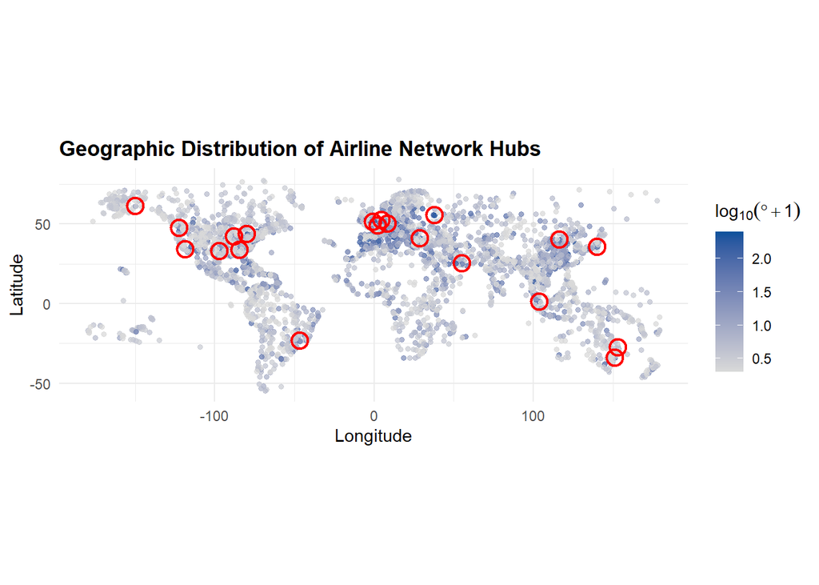

```r
# Prepare node-level data for the geographic visualization
df.nodes <- data.frame(
  longitude = as.numeric(V(g)$longitude),
  latitude = as.numeric(V(g)$latitude),
  degree = degree(g)
)

# Re-use the same top-20 betweenness airports computed in Part C.2
df.nodes$is_top_20_betweenness <- seq_len(vcount(g)) %in%
  top.20.betw.idx

# Remove airports without valid geographic coordinates
df.nodes.geo <- df.nodes[
  !is.na(df.nodes$longitude) & !is.na(df.nodes$latitude),
]

# Plot airports by location and highlight structural bridges
ggplot(df.nodes.geo, aes(x = longitude, y = latitude)) +
  geom_point(
    aes(colour = log10(degree + 1)),
    size = 1.2,
    alpha = 0.75
  ) +
  scale_colour_gradient(
    name = expression(log[10](degree + 1)),
    low = "grey85",
    high = "#08519c"
  ) +
  geom_point(
    data = df.nodes.geo[df.nodes.geo$is_top_20_betweenness, ],
    aes(x = longitude, y = latitude),
    shape = 1,
    colour = "red",
    size = 4,
    stroke = 1.3
  ) +
  coord_fixed() +
  labs(
    title = "Geographic Distribution of Airline Network Hubs",
    x = "Longitude",
    y = "Latitude"
  ) +
  theme_minimal(base_size = 11) +
  theme(plot.title = element_text(face = "bold"))
```

2. *(Moderate)* **Predicted-routes visualization.** Using `visNetwork`, create an interactive plot showing the top-10 predicted links from D.2 overlaid on the existing network. Use a visually distinct edge style (e.g., dashed red) for the predicted links versus existing routes. Restrict the displayed network to a manageable subset (e.g., the 100 highest-degree airports plus the endpoints of all predicted links) so the plot is readable. Include a brief caption explaining what your visualization shows. *Hint: `visNetwork` takes two data.frames — one for nodes (with `id`, `label`) and one for edges (with `from`, `to`, plus optional `dashes` and `color`). Use `induced_subgraph()` to extract a readable subgraph and `as_data_frame(sub_g, what = "edges")` to get its edges.* `[1 point]`

```r
library(visNetwork)
```

```r
# Select a readable subset of the network
top.100.degree.idx <- order(degree(g), decreasing = TRUE)[1:100]
pred.endpoints.idx <- unique(as.integer(m.pairs[top10.idx, ]))
keep.idx <- unique(c(top.100.degree.idx, pred.endpoints.idx))

g.sub <- induced_subgraph(g, keep.idx)

# Build node data for visNetwork
node.names <- V(g.sub)$name
v.degree <- degree(g)

# Map each airport's full name to its 3-letter IATA code for readable labels;
# fall back to the full name when an IATA code is missing.
iata.by.name <- setNames(dt.airports$iata, dt.airports$name)
node.iata <- iata.by.name[node.names]
node.iata[is.na(node.iata) | node.iata == ""] <-
  node.names[is.na(node.iata) | node.iata == ""]

df.vis.nodes <- data.frame(
  id = node.names,
  label = node.iata,
  title = node.names,
  value = as.numeric(v.degree[node.names])
)

# Existing routes in the selected subgraph
df.sub.edges <- as_data_frame(g.sub, what = "edges")

df.vis.edges.existing <- data.frame(
  from = df.sub.edges$from,
  to = df.sub.edges$to,
  color = "#AAAAAA",
  width = 1,
  dashes = FALSE,
  title = "Existing route"
)

# Top-10 predicted links from Part D.2
df.vis.edges.predicted <- data.frame(
  from = V(g)$name[m.pairs[top10.idx, 1]],
  to = V(g)$name[m.pairs[top10.idx, 2]],
  color = "red",
  width = 3,
  dashes = TRUE,
  title = paste0(
    "Predicted route | Adamic-Adar = ",
    round(aa.vec[top10.idx], 4)
  )
)

# Combine existing and predicted routes
df.vis.edges <- rbind(
  df.vis.edges.existing,
  df.vis.edges.predicted
)

df.vis.edges <- df.vis.edges[
  !is.na(df.vis.edges$from) & !is.na(df.vis.edges$to),
]

# Render interactive network
vis.network <- visNetwork(
  df.vis.nodes,
  df.vis.edges,
  main = "Top-10 Predicted Routes on the Airline Network"
)

vis.network <- visNodes(
  vis.network,
  scaling = list(min = 5, max = 25)
)

vis.network <- visEdges(
  vis.network,
  smooth = FALSE
)

vis.network <- visOptions(
  vis.network,
  highlightNearest = TRUE,
  nodesIdSelection = TRUE
)

vis.network <- visPhysics(
  vis.network,
  enabled = FALSE,
  stabilization = list(enabled = TRUE, iterations = 1000)
)

vis.network
```

[interactive chart not shown]

The plot displays 115 airports — the 100 highest-degree airports plus the 20 endpoints of the top-10 predicted links (only 5 of which are themselves top-100 hubs) — with IATA codes as labels, node size scaled by degree, and the full airport name available on hover. Existing routes are drawn as 2,173 thin gray edges forming a dense hub-to-hub mesh, while the 10 predicted links are overlaid as dashed red edges; almost every red edge connects a smaller airport (e.g., EIN, HAU, LPQ, STX) to either a major hub or another mid-sized airport on the other side of the world. This makes the Adamic-Adar logic tangible: the predicted pairs are not “two big hubs missing a link” but rather airport pairs that share many high-degree *common neighbors* — passengers are already being routed indirectly through those shared hubs (visible as the surrounding gray mesh), and a nonstop service would simply short-circuit that diverted demand.